# Titanic Data Analysis

Welcome to my analysis of the Titanic Data Set.

## Introduction and Main Question

Though during this analysis I will endeavour to answer many subquestions, my main premise is there will be a difference among male and female survival rates from the Titanic. The results will be held to $\alpha$ = 0.01, and are formally presented as follows: $$H_0: \mu_m - \mu_f = 0$$ $$H_1: \mu_m - \mu_f < 0$$ Where $\mu$ is the survival rate for each respective gender.

This test will be 1-tailed, Z-Score test; as I hypothesize females will have a distinctly higher survival rate comparetively to males. We begin by importing relevant packages, reading in the data, and printing a few rows to examine what we have.

## Table Descriptions

### VARIABLE DESCRIPTIONS:

- survival Survival (0 = No; 1 = Yes)
- pclass Passenger Class (1 = 1st; 2 = 2nd; 3 = 3rd)
- name Name
- sex Sex
- age Age
- sibsp Number of Siblings/Spouses Aboard
- parch Number of Parents/Children Aboard
- ticket Ticket Number
- fare Passenger Fare
- cabin Cabin
- embarked Port of Embarkation (C = Cherbourg; Q = Queenstown; S = Southampton)

### SPECIAL NOTES:

Pclass is a proxy for socio-economic status (SES) 1st ~ Upper; 2nd ~ Middle; 3rd ~ Lower

Age is in Years; Fractional if Age less than One (1) If the Age is Estimated, it is in the form xx.5

With respect to the family relation variables (i.e. sibsp and parch) some relations were ignored. The following are the definitions used for sibsp and parch.

- Sibling: Brother, Sister, Stepbrother, or Stepsister of Passenger Aboard Titanic
- Spouse: Husband or Wife of Passenger Aboard Titanic (Mistresses and Fiances Ignored)
- Parent: Mother or Father of Passenger Aboard Titanic
- Child: Son, Daughter, Stepson, or Stepdaughter of Passenger Aboard Titanic

Other family relatives excluded from this study include cousins, nephews/nieces, aunts/uncles, and in-laws. Some children travelled only with a nanny, therefore parch=0 for them. As well, some travelled with very close friends or neighbors in a village, however, the definitions do not support such relations.

```python
#import packages
import pandas as pd
import numpy as np
import seaborn as sns
import matplotlib.pyplot as plt
from scipy import stats
%matplotlib inline
```

```python
#load data
df = pd.read_csv("titanic-data.csv")
df.head()
```

|  | PassengerId | Survived | Pclass | Name | Sex | Age | SibSp | Parch | Ticket | Fare | Cabin | Embarked |
| --- | --- | --- | --- | --- | --- | --- | --- | --- | --- | --- | --- | --- |
| 0 | 1 | 0 | 3 | Braund, Mr. Owen Harris | male | 22.0 | 1 | 0 | A/5 21171 | 7.2500 | NaN | S |
| 1 | 2 | 1 | 1 | Cumings, Mrs. John Bradley (Florence Briggs Th... | female | 38.0 | 1 | 0 | PC 17599 | 71.2833 | C85 | C |
| 2 | 3 | 1 | 3 | Heikkinen, Miss. Laina | female | 26.0 | 0 | 0 | STON/O2. 3101282 | 7.9250 | NaN | S |
| 3 | 4 | 1 | 1 | Futrelle, Mrs. Jacques Heath (Lily May Peel) | female | 35.0 | 1 | 0 | 113803 | 53.1000 | C123 | S |
| 4 | 5 | 0 | 3 | Allen, Mr. William Henry | male | 35.0 | 0 | 0 | 373450 | 8.0500 | NaN | S |

```python
df.columns.to_series().groupby(df.dtypes).groups
```

```
{dtype('int64'): Index(['PassengerId', 'Survived', 'Pclass', 'SibSp', 'Parch'], dtype='object'),
 dtype('float64'): Index(['Age', 'Fare'], dtype='object'),
 dtype('O'): Index(['Name', 'Sex', 'Ticket', 'Cabin', 'Embarked'], dtype='object')}
```

## Defining our functions and Data Wrangling

Some initial functions to begin working with the data. Also directly beneath my functions are any statements to modify the original data set necessary to the rest of the analysis.

*please note my naming convention for a function I plan on using in a .apply is appFunction - short for applyFunction*

```python
def appGender(row):
    """Returns 0 for male, 1 for Female

    Used in df.apply to change 'male' / 'female' to 0 / 1 respectively.
    """
    if row['Sex'] == 'male': return 0
    else: return 1
```

```python
df['gender'] = df.apply(appGender, axis=1)
df.head()
```

|  | PassengerId | Survived | Pclass | Name | Sex | Age | SibSp | Parch | Ticket | Fare | Cabin | Embarked | gender |
| --- | --- | --- | --- | --- | --- | --- | --- | --- | --- | --- | --- | --- | --- |
| 0 | 1 | 0 | 3 | Braund, Mr. Owen Harris | male | 22.0 | 1 | 0 | A/5 21171 | 7.2500 | NaN | S | 0 |
| 1 | 2 | 1 | 1 | Cumings, Mrs. John Bradley (Florence Briggs Th... | female | 38.0 | 1 | 0 | PC 17599 | 71.2833 | C85 | C | 1 |
| 2 | 3 | 1 | 3 | Heikkinen, Miss. Laina | female | 26.0 | 0 | 0 | STON/O2. 3101282 | 7.9250 | NaN | S | 1 |
| 3 | 4 | 1 | 1 | Futrelle, Mrs. Jacques Heath (Lily May Peel) | female | 35.0 | 1 | 0 | 113803 | 53.1000 | C123 | S | 1 |
| 4 | 5 | 0 | 3 | Allen, Mr. William Henry | male | 35.0 | 0 | 0 | 373450 | 8.0500 | NaN | S | 0 |

## Exploring the data

Beginning with a over-arching view of the population, then drilling down into the female vs male samples.

### Population Statistics

Now that we've gotten a good clean table to work from, and added additional columns for analytical purposes, we can begin to look at how the entire population did, then subsection it down and compare.

```python
df.describe()
```

|  | PassengerId | Survived | Pclass | Age | SibSp | Parch | Fare | gender |
| --- | --- | --- | --- | --- | --- | --- | --- | --- |
| count | 891.000000 | 891.000000 | 891.000000 | 714.000000 | 891.000000 | 891.000000 | 891.000000 | 891.000000 |
| mean | 446.000000 | 0.383838 | 2.308642 | 29.699118 | 0.523008 | 0.381594 | 32.204208 | 0.352413 |
| std | 257.353842 | 0.486592 | 0.836071 | 14.526497 | 1.102743 | 0.806057 | 49.693429 | 0.477990 |
| min | 1.000000 | 0.000000 | 1.000000 | 0.420000 | 0.000000 | 0.000000 | 0.000000 | 0.000000 |
| 25% | 223.500000 | 0.000000 | 2.000000 | 20.125000 | 0.000000 | 0.000000 | 7.910400 | 0.000000 |
| 50% | 446.000000 | 0.000000 | 3.000000 | 28.000000 | 0.000000 | 0.000000 | 14.454200 | 0.000000 |
| 75% | 668.500000 | 1.000000 | 3.000000 | 38.000000 | 1.000000 | 0.000000 | 31.000000 | 1.000000 |
| max | 891.000000 | 1.000000 | 3.000000 | 80.000000 | 8.000000 | 6.000000 | 512.329200 | 1.000000 |

#### Holy insights!

Let's break down some key numbers:

- There are 891 passengers in the set.
- The overall survival rate was ~38% ($\mu = 38\%$)
- Of the passengers, ~35% were female.

To examine our hypothesis we we look to see if females have a abnormally larger survival rate than males.

```python
# a look at females general population statistics
df[df['gender'] == 1].describe()
```

|  | PassengerId | Survived | Pclass | Age | SibSp | Parch | Fare | gender |
| --- | --- | --- | --- | --- | --- | --- | --- | --- |
| count | 314.000000 | 314.000000 | 314.000000 | 261.000000 | 314.000000 | 314.000000 | 314.000000 | 314.0 |
| mean | 431.028662 | 0.742038 | 2.159236 | 27.915709 | 0.694268 | 0.649682 | 44.479818 | 1.0 |
| std | 256.846324 | 0.438211 | 0.857290 | 14.110146 | 1.156520 | 1.022846 | 57.997698 | 0.0 |
| min | 2.000000 | 0.000000 | 1.000000 | 0.750000 | 0.000000 | 0.000000 | 6.750000 | 1.0 |
| 25% | 231.750000 | 0.000000 | 1.000000 | 18.000000 | 0.000000 | 0.000000 | 12.071875 | 1.0 |
| 50% | 414.500000 | 1.000000 | 2.000000 | 27.000000 | 0.000000 | 0.000000 | 23.000000 | 1.0 |
| 75% | 641.250000 | 1.000000 | 3.000000 | 37.000000 | 1.000000 | 1.000000 | 55.000000 | 1.0 |
| max | 889.000000 | 1.000000 | 3.000000 | 63.000000 | 8.000000 | 6.000000 | 512.329200 | 1.0 |

```python
# a look at male general population statistics
df[df['gender'] == 0].describe()
```

|  | PassengerId | Survived | Pclass | Age | SibSp | Parch | Fare | gender |
| --- | --- | --- | --- | --- | --- | --- | --- | --- |
| count | 577.000000 | 577.000000 | 577.000000 | 453.000000 | 577.000000 | 577.000000 | 577.000000 | 577.0 |
| mean | 454.147314 | 0.188908 | 2.389948 | 30.726645 | 0.429809 | 0.235702 | 25.523893 | 0.0 |
| std | 257.486139 | 0.391775 | 0.813580 | 14.678201 | 1.061811 | 0.612294 | 43.138263 | 0.0 |
| min | 1.000000 | 0.000000 | 1.000000 | 0.420000 | 0.000000 | 0.000000 | 0.000000 | 0.0 |
| 25% | 222.000000 | 0.000000 | 2.000000 | 21.000000 | 0.000000 | 0.000000 | 7.895800 | 0.0 |
| 50% | 464.000000 | 0.000000 | 3.000000 | 29.000000 | 0.000000 | 0.000000 | 10.500000 | 0.0 |
| 75% | 680.000000 | 0.000000 | 3.000000 | 39.000000 | 0.000000 | 0.000000 | 26.550000 | 0.0 |
| max | 891.000000 | 1.000000 | 3.000000 | 80.000000 | 8.000000 | 5.000000 | 512.329200 | 0.0 |

#### Digging Deeper: A first look at Female v.s. Male populations

From these two tables we can get some real insight to run on, we now know:

- There were 314 females, and 577 males.
- Survival rate = Males: 18% | Females: 74%
- Average Age = Males: 30 | Females: 27

#### Checking correlations at a higher level

A quick look at Perasons product-moment correlation coefficient to corroborate our initial findings.

```python
pearson = np.corrcoef(x=df['gender'], y=df['Survived'])
print(pearson.mean())
```

```
0.771675690329
```

Yes, we can see that gender and survived are very positively correlated (keep in mind 1 is female and 1 is survived).

### Taking it even further

Now it's time to look at our data via some neat graphs.

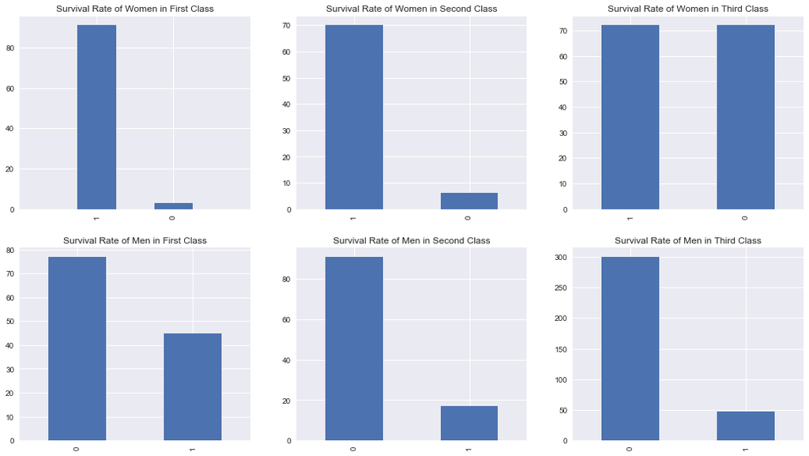

```python
# establlish our subplots, going to go with a 2 by 3 grid to examine relationships between gender, class, and survival.
fig, axes = plt.subplots(2, 3, figsize=(18, 10))

# Starting with women in first class -> second -> third; then men first -> second -> third
ax1 = plt.subplot2grid((2, 3), (0,0))
df.Survived[(df.gender == 1) & (df.Pclass == 1)].value_counts().plot(kind='bar')
ax1.set_xlim(-1, 2)
plt.title("Survival Rate of Women in First Class")

ax2 = plt.subplot2grid((2, 3), (0, 1))
df.Survived[(df.gender == 1) & (df.Pclass == 2)].value_counts().plot(kind='bar')
plt.title("Survival Rate of Women in Second Class")

ax3 = plt.subplot2grid((2, 3), (0, 2))
df.Survived[(df.gender == 1) & (df.Pclass == 3)].value_counts().plot(kind='bar')
plt.title("Survival Rate of Women in Third Class")

ax4 = plt.subplot2grid((2, 3), (1, 0))
df.Survived[(df.gender == 0) & (df.Pclass == 1)].value_counts().plot(kind='bar')
plt.title("Survival Rate of Men in First Class")

ax5 = plt.subplot2grid((2, 3), (1, 1))
df.Survived[(df.gender == 0) & (df.Pclass == 2)].value_counts().plot(kind='bar')
plt.title("Survival Rate of Men in Second Class")

ax6 = plt.subplot2grid((2, 3), (1, 2))
df.Survived[(df.gender == 0) & (df.Pclass == 3)].value_counts().plot(kind='bar')
plt.title("Survival Rate of Men in Third Class")
```

#### Insights from Survival rates split by gender and class

From the above charts we can see a female passenger is more likely to have been saved in every class comparetively to their male counterparts. The subclass presented here with the highest odds of surviving (by no surprise) are the females of first class. The lowest odds can be found between males of second and third class, who did not fair so well.

To present the same findings proportionally across the board:

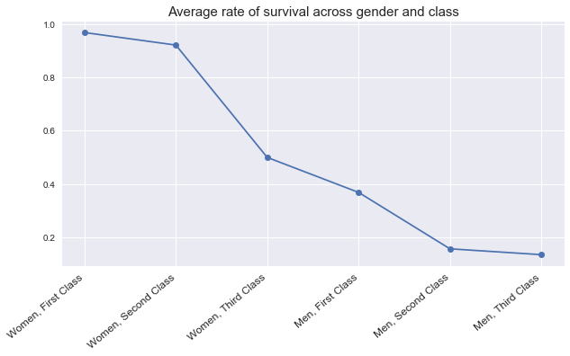

```python
# creating a plot of chances of survival by class and gender!
data = [
    df.Survived[(df.gender == 1) & (df.Pclass == 1)].mean(),
    df.Survived[(df.gender == 1) & (df.Pclass == 2)].mean(),
    df.Survived[(df.gender == 1) & (df.Pclass == 3)].mean(),
    df.Survived[(df.gender == 0) & (df.Pclass == 1)].mean(),
    df.Survived[(df.gender == 0) & (df.Pclass == 2)].mean(),
    df.Survived[(df.gender == 0) & (df.Pclass == 3)].mean(),
]
labels = [
    "",
    "Women, First Class",
    "Women, Second Class",
    "Women, Third Class",
    "Men, First Class",
    "Men, Second Class",
    "Men, Third Class"
]
x = [1, 2, 3, 4, 5, 6]
fig, ax = plt.subplots(figsize=(10, 5))
ax.plot(x, data, 'o-')
ax.set_xticklabels(labels, rotation=40, ha='right', fontsize=12)
ax.set_title("Average rate of survival across gender and class", fontsize=15)
```

#### Proportionally Safe

This paints a bleak picture for myself, a male, most likely second-class traveler, but *C'est la vie*.

To continue onto the numbers now -

```python
fem_mean = df.Survived[(df.gender == 1) & (df.Pclass == 1)].mean()
print(fem_mean)
```

```
0.9680851063829787
```

Approximately 96% of females in first class survied the incident.

Compared to males in third class?

```python
male_mean = df.Survived[(df.gender == 0) & (df.Pclass == 3)].mean()
print(male_mean)
```

```
0.13544668587896252
```

Well darn, ~13% are not good odds by any standard.

Let's take a look at the Z-Scores of our various subgroups of the population.

```python
fem_z = (fem_mean - df.Survived.mean()) / df.Survived.std(ddof=0)
print(fem_z)
```

```
1.2013644144488933
```

```python
fem_z_toMale = (fem_mean - df.Survived[(df.gender == 0)].mean()) / df.Survived[(df.gender == 0)].std(ddof=0)
print(fem_z_toMale)
```

```
1.9905621426418676
```

So close. A 1.99 Z-Score, rejection of the null does not make though. Still, it is evident females did have quite different odds than males on this foregone cruiseship of yore.

## Conclusion of main premise

### Resources Consulted

[Jupyter Notebook from Kaggle on Titanic Analysis](http://nbviewer.jupyter.org/github/agconti/kaggle-titanic/blob/master/Titanic.ipynb)

[Jupyter Notebook on Matplotlib](http://nbviewer.jupyter.org/github/jrjohansson/scientific-python-lectures/blob/master/Lecture-4-Matplotlib.ipynb)

[PyPlot Docs](http://matplotlib.org/api/pyplot_api.html#matplotlib.pyplot.bar)

[Pandas Docs](http://pandas.pydata.org/pandas-docs/stable/dsintro.html)